# 4-annotated-pre-analysis-plan

## A closer look at behavioral outcomes

### Are attitudinal changes associated with behavioral changes?

*paper*: First, we observe that attitudinal outcomes are much more common in our sample overall, outnumbering behavioral outcomes by 355 to 145

```r
table(dat$scale_type)
```

```
##
## attitudes  behavior
##       355       145
```

```r
# by study design?
dat %>% group_by(scale_type, study_design) %>% tally()
```

```
## # A tibble: 6 × 3
## # Groups:   scale_type [2]
##   scale_type study_design           n
##   <fct>      <chr>              <int>
## 1 attitudes  observational        116
## 2 attitudes  quasi-experimental   122
## 3 attitudes  rct                  117
## 4 behavior   observational         28
## 5 behavior   quasi-experimental    54
## 6 behavior   rct                   63
```

```r
# by categories of behavior/attitudes?
dat %>% group_by(study_design, behavior_type) %>% tally()
```

```
## # A tibble: 14 × 3
## # Groups:   study_design [3]
##    study_design       behavior_type     n
##    <chr>              <fct>         <int>
##  1 observational      attitude        116
##  2 observational      bystander         6
##  3 observational      perpetration     15
##  4 observational      victimization     7
##  5 quasi-experimental attitude        122
##  6 quasi-experimental bystander        11
##  7 quasi-experimental involvement       6
##  8 quasi-experimental perpetration     21
##  9 quasi-experimental victimization    16
## 10 rct                attitude        117
## 11 rct                bystander        10
## 12 rct                involvement       3
## 13 rct                perpetration     28
## 14 rct                victimization    22
```

### Do behavior outcomes become more likely over time?

```r
range(dat$year)
```

```
## [1] 1986 2018
```

```r
dat <- dat %>%
  mutate(decade = case_when(
    year <= 1989 ~ "1980s",
    year >= 1990 & year <= 1999 ~ "1990s",
    year >= 2000 & year <= 2009 ~ "2000s",
    year >= 2010 ~ "2010s",
    TRUE ~ "Other"
  ))

dat %>%  group_by(decade, scale_type) %>%
  summarize(count = n()) %>%
    pivot_wider(names_from = scale_type, values_from = count)
```

```
## # A tibble: 4 × 3
## # Groups:   decade [4]
##   decade attitudes behavior
##   <chr>      <int>    <int>
## 1 1980s          7       NA
## 2 1990s        135       29
## 3 2000s         70       19
## 4 2010s        143       97
```

```r
# just for curiousity how many *studiess* are in each decade
dat %>% group_by(unique_paper_id) %>% slice(1) %>% group_by(decade) %>% tally()
```

```
## # A tibble: 4 × 2
##   decade     n
##   <chr>  <int>
## 1 1980s      6
## 2 1990s     63
## 3 2000s     48
## 4 2010s    109
```

```r
# sanity check
6 + 63 + 48 + 109 == length(unique(dat$unique_paper_id)) # passed
```

```
## [1] TRUE
```

```r
# what was the earliest study to measure behavior as we conceive it?
dat %>% filter(scale_type == 'behavior') %>%
  arrange(year) %>%
  select(author, year, paper_title) %>% head()
```

```
## # A tibble: 6 × 3
##   author   year paper_title
##   <chr>   <int> <chr>
## 1 gilbert  1991 Changing the Sexual Agressive Suportive Attitudes of Men: A Psy…
## 2 gibson   1991 An intervention designed to modify attitudes toward acquaintanc…
## 3 gibson   1991 An intervention designed to modify attitudes toward acquaintanc…
## 4 gibson   1991 An intervention designed to modify attitudes toward acquaintanc…
## 5 gibson   1991 An intervention designed to modify attitudes toward acquaintanc…
## 6 nagler   1993 Effect of an acquaintance rape prevention program on rape attit…
```

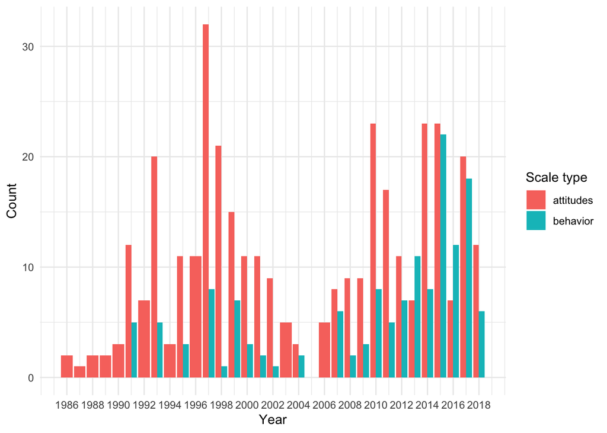

```r
year_plot <- ggplot(dat, aes(x = year, fill = scale_type)) +
  geom_bar(position = "dodge") +
  scale_fill_manual(values = c("attitudes" = "#F8766D", "behavior" = "#00BFC4")) +
  labs(x = "Year", y = "Count", fill = "Scale type") +
  theme_minimal() +
  scale_x_continuous(breaks = seq(min(dat$year), max(dat$year), by = 2))
year_plot
```

```r
png(filename = './results/year-plot.png', width = 1920/2, height = 1080/2)
year_plot
dev.off()
```

*pap*: “What is the association between attitudes and behaviors (temporal match) – this answers our question of ‘should we care about attitudes?’” …The covariation of attitudes and behaviors will be assessed in the full sample of studies

*paper*: To assess this, we look at studies that measure both behavioral and attitudinal changes and estimate the average correlation. In the entire universe of studies reporting both types of outcomes, we see an average Pearson’s product-moment correlation of 0.14; this is a modest, positive relationship, but with a p-value of 0.278, it is not statistically distinguishable from zero.

```r
has_both <- dat %>%
  filter(all(c('attitudes', 'behavior') %in% scale_type)) %>%
  group_by(unique_study_id, scale_type) %>%
  mutate(mean_d = mean(d),
         mean_var_d = mean(var_d),
         mean_se_d = mean(se_d)) %>%
  select(author, year, paper_title, unique_study_id, intervention_name,
         study_design, mean_d, mean_var_d, mean_se_d,
         ra, labels, scale_type) %>%
  slice(1) %>%
  pivot_wider(
    id_cols = c(author, year, paper_title, unique_study_id,
                intervention_name,
                unique_study_id, study_design, ra, labels),
    names_from = c(scale_type),
    values_from = c(mean_d, mean_var_d, mean_se_d))

cor.test(x = has_both$mean_d_attitudes,
         y = has_both$mean_d_behavior)
```

```
##
##  Pearson's product-moment correlation
##
## data:  has_both$mean_d_attitudes and has_both$mean_d_behavior
## t = 1.0937, df = 59, p-value = 0.2785
## alternative hypothesis: true correlation is not equal to 0
## 95 percent confidence interval:
##  -0.1149387  0.3793181
## sample estimates:
##       cor
## 0.1409621
```

```r
# by study type?
has_both %>%
  split(.$study_design) %>%
  map(~cor.test(.$mean_d_attitudes, .$mean_d_behavior))
```

```
## $observational
##
##  Pearson's product-moment correlation
##
## data:  .$mean_d_attitudes and .$mean_d_behavior
## t = -2.4667, df = 10, p-value = 0.03329
## alternative hypothesis: true correlation is not equal to 0
## 95 percent confidence interval:
##  -0.87876886 -0.06360783
## sample estimates:
##       cor
## -0.615057
##
##
## $`quasi-experimental`
##
##  Pearson's product-moment correlation
##
## data:  .$mean_d_attitudes and .$mean_d_behavior
## t = 1.922, df = 20, p-value = 0.06897
## alternative hypothesis: true correlation is not equal to 0
## 95 percent confidence interval:
##  -0.03210317  0.69993799
## sample estimates:
##       cor
## 0.3948496
##
##
## $rct
##
##  Pearson's product-moment correlation
##
## data:  .$mean_d_attitudes and .$mean_d_behavior
## t = 0.73639, df = 25, p-value = 0.4683
## alternative hypothesis: true correlation is not equal to 0
## 95 percent confidence interval:
##  -0.2480422  0.4981379
## sample estimates:
##       cor
## 0.1457059
```

```r
# not in paper but what's the slope of these lines
has_both %>%
  split(.$study_design) %>%
  map(~sum_lm(y = mean_d_behavior,
              x = mean_d_attitudes,
              dat = .))
```

```
## $observational
##                  Estimate Std. Error  t value Pr(>|t|)
## (Intercept)       0.38439    0.15982  2.40513  0.03699
## mean_d_attitudes -1.14645    0.46476 -2.46674  0.03329
##
## $`quasi-experimental`
##                  Estimate Std. Error t value Pr(>|t|)
## (Intercept)       0.03914    0.06713 0.58302  0.56640
## mean_d_attitudes  0.33927    0.17652 1.92199  0.06897
##
## $rct
##                  Estimate Std. Error t value Pr(>|t|)
## (Intercept)       0.04764    0.05594 0.85174  0.40244
## mean_d_attitudes  0.07700    0.10457 0.73639  0.46835
```

### Dat for forest plot and sign tests

```r
dat_for_forest_plot <- readRDS(file = '../data/sa_meta_data_for_analysis.rds') %>%
  select(unique_study_id, scale_type, everything()) %>%
  filter(study_design == 'rct') %>%
  group_by(unique_study_id) %>%
         filter(all(c('attitudes', 'behavior') %in% scale_type)) %>%
  mutate(study_names = paste0(tools::toTitleCase(word(author)), " ",
                              year, " ", "(", scale_type, ")")) %>%
  group_by(unique_paper_id, scale_type) %>%
  mutate(d = mean(d), var_d = mean(var_d), se_d = mean(se_d)) %>%
  slice(1) %>%
  ungroup(scale_type) %>%
  mutate(mean_se = mean(se_d)) %>%
  arrange(mean_se) %>%
  ungroup() %>%
  select(study_names, d, se_d,
         scale_type, unique_paper_id)

# sign test: how many studies have an attitude d that's > behavior d
dat_for_forest_plot %>%
  group_by(unique_paper_id) %>%
  summarise(mean_d_attitude = mean(d[scale_type == "attitudes"]),
            mean_d_behavior = mean(d[scale_type == "behavior"])) %>%
  mutate(comparison = case_when(
    mean_d_attitude > mean_d_behavior ~ "Higher",
    mean_d_attitude == mean_d_behavior ~ "Same",
    mean_d_attitude < mean_d_behavior ~ "Lower"
  )) %>%
  count(comparison) %>%
  rename(Comparison = comparison, Count = n)
```

```
## # A tibble: 2 × 2
##   Comparison Count
##   <chr>      <int>
## 1 Higher        15
## 2 Lower          6
```

```r
binom.test(15, 21, 0.5)
```

```
##
##  Exact binomial test
##
## data:  15 and 21
## number of successes = 15, number of trials = 21, p-value = 0.07835
## alternative hypothesis: true probability of success is not equal to 0.5
## 95 percent confidence interval:
##  0.4782489 0.8871906
## sample estimates:
## probability of success
##              0.7142857
```

```r
# now the whole thing but not filtering on RCTs
readRDS(file = '../data/sa_meta_data_for_analysis.rds') %>%
  select(unique_study_id, scale_type, everything()) %>%
  group_by(unique_study_id) %>%
         filter(all(c('attitudes', 'behavior') %in% scale_type)) %>%
  mutate(study_names = paste0(tools::toTitleCase(word(author)), " ",
                              year, " ", "(", scale_type, ")")) %>%
  group_by(unique_paper_id, scale_type) %>%
  mutate(d = mean(d), var_d = mean(var_d), se_d = mean(se_d)) %>%
  slice(1) %>%
  ungroup(scale_type) %>%
  mutate(mean_se = mean(se_d)) %>%
  arrange(mean_se) %>%
  ungroup() %>%
    group_by(unique_paper_id) %>%
  summarise(mean_d_attitude = mean(d[scale_type == "attitudes"]),
            mean_d_behavior = mean(d[scale_type == "behavior"])) %>%
  mutate(comparison = case_when(
    mean_d_attitude > mean_d_behavior ~ "Higher",
    mean_d_attitude == mean_d_behavior ~ "Same",
    mean_d_attitude < mean_d_behavior ~ "Lower"
  )) %>%
  count(comparison) %>%
  rename(Comparison = comparison, Count = n)
```

```
## # A tibble: 3 × 2
##   Comparison Count
##   <chr>      <int>
## 1 Higher        36
## 2 Lower         12
## 3 Same           1
```

```r
binom.test(36, (36 + 12 + 1), 0.5)
```

```
##
##  Exact binomial test
##
## data:  36 and (36 + 12 + 1)
## number of successes = 36, number of trials = 49, p-value = 0.001403
## alternative hypothesis: true probability of success is not equal to 0.5
## 95 percent confidence interval:
##  0.5891829 0.8505293
## sample estimates:
## probability of success
##              0.7346939
```

### Forest Plot (Figure)

```r
head(dat_for_forest_plot) # checking we've already created subset (chunk above)
```

```
## # A tibble: 6 × 5
##   study_names                   d   se_d scale_type unique_paper_id
##   <chr>                     <dbl>  <dbl> <fct>                <int>
## 1 Senn 2017 (attitudes)    0.520  0.0878 attitudes              208
## 2 Senn 2017 (behavior)     0.0705 0.0841 behavior               208
## 3 Foubert 2007 (attitudes) 0.166  0.0894 attitudes              101
## 4 Foubert 2007 (behavior)  0.103  0.0894 behavior               101
## 5 Foshee 2012 (attitudes)  0.37   0.114  attitudes              148
## 6 Foshee 2012 (behavior)   0.574  0.114  behavior               148
```

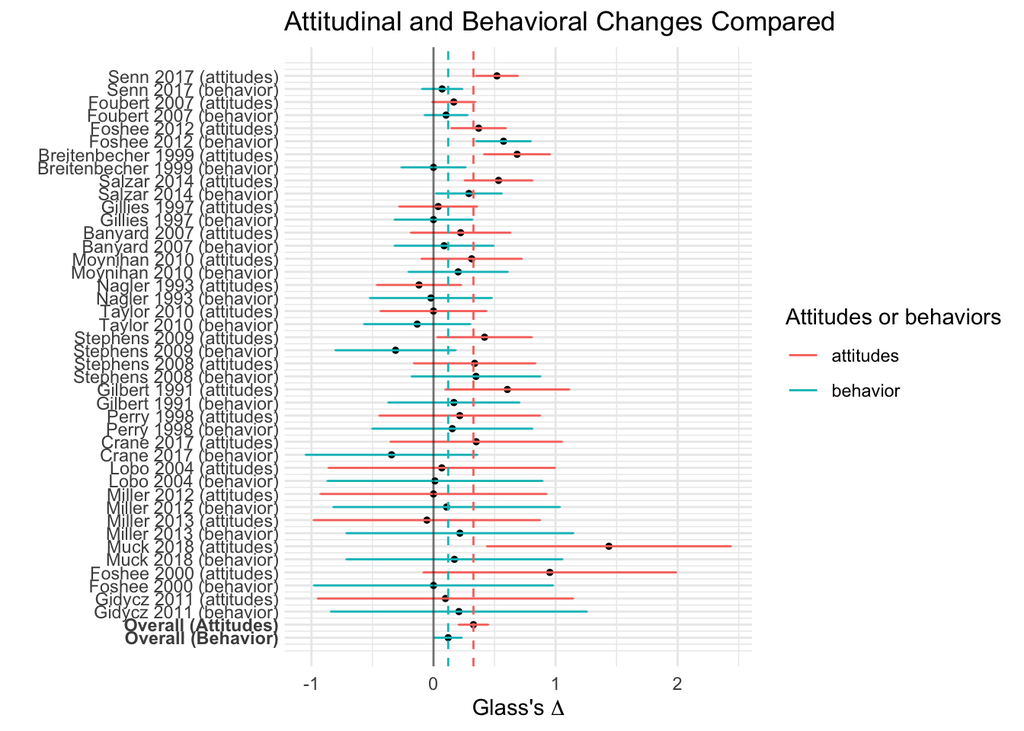

```r
# overall effect size
overall_forest <- dat_for_forest_plot %>%
  split(.$scale_type) %>%
  map(~robust(x = rma(yi = .$d,  sei = .$se_d),
              cluster = .$unique_paper_id))


dat_for_forest_plot <- dat_for_forest_plot %>%
  add_row(study_names = "Overall (Attitudes)",
          d = overall_forest[[1]]$beta,
          se_d = overall_forest[[1]]$se,
          scale_type = "attitudes",
          unique_paper_id = NA) %>%
  add_row(study_names = "Overall (Behavior)",
          d = overall_forest[[2]]$beta,
          se_d = overall_forest[[2]]$se,
          scale_type = "behavior",
          unique_paper_id = NA) %>%
  mutate(index = row_number()) %>%
  relocate(index, .before = 1)

# plot

p <- dat_for_forest_plot %>%
  ggplot(aes(y = index, x = d, xmin = d - (1.96 * se_d),
             xmax = d + (1.96 * se_d))) +
  geom_point(size = 1) +
  geom_errorbarh(height = .1, aes(color = scale_type)) +
  geom_vline(xintercept = 0, color = "black", alpha = .5) +
  scale_x_continuous(name = expression(paste("Glass's", " ", Delta))) +
  scale_y_continuous(name = "", breaks = 1:length(dat_for_forest_plot$study_names),
                     trans = "reverse", labels = dat_for_forest_plot$study_names) +
  ylab("Study") +
  geom_vline(xintercept = overall_forest$attitudes$beta, color = '#F8766D', lty = 'dashed') +
  geom_vline(xintercept = overall_forest$behavior$beta, color = '#00BFC4', lty = 'dashed') +
  labs(color = "Attitudes or behaviors") +
  theme_minimal() +
  theme(axis.text.y = element_text(face = ifelse(
    dat_for_forest_plot$study_names %in%
      c("Overall (Attitudes)", "Overall (Behavior)"),
    "bold", "plain"),
    margin = margin(t = 0.5, b = 0.5, unit = "cm"))) +
  ggtitle("Attitudinal and Behavioral Changes Compared")
p
```

```r
# getting a warning message about vectorized input is not officially supported
# and results may change in future versions of ggplot2.
# Guess we'll hope they don't? :)

png(filename = './results/4-ggplot-forest-plot.png', width = 1920/2, height = 1080/2)
p
dev.off()
```

```r
# figure out how to make this plot legible. Do I need two rows per
# useful for figuring out colors & such: `ggplot_build(p)$data`

## TODO:  sctterplot: y = d (behavior), x = d (attitudes)
```

### Assessing differences between categories of behavioral outcomes

*pap*: Compare the effect size of behavioral outcomes for studies with random assignment vs. quasi-experimental studies, both in the short- and in the long-term.

```r
# overall estimates
# first, how many are in each category?
dat %>% group_by(study_design, behavior_type) %>% tally()
```

```
## # A tibble: 14 × 3
## # Groups:   study_design [3]
##    study_design       behavior_type     n
##    <chr>              <fct>         <int>
##  1 observational      attitude        116
##  2 observational      bystander         6
##  3 observational      perpetration     15
##  4 observational      victimization     7
##  5 quasi-experimental attitude        122
##  6 quasi-experimental bystander        11
##  7 quasi-experimental involvement       6
##  8 quasi-experimental perpetration     21
##  9 quasi-experimental victimization    16
## 10 rct                attitude        117
## 11 rct                bystander        10
## 12 rct                involvement       3
## 13 rct                perpetration     28
## 14 rct                victimization    22
```

```r
# so there are zero pre-post designs that ask about involvement
dat %>% filter(study_design == 'pre-post', behavior_type == 'involvement') %>% count()
```

```
## # A tibble: 1 × 1
##       n
##   <int>
## 1     0
```

```r
# Two possible solutions to this. 1) group studies into RCT vs non-randomized,
# and because we specify this in the pre-analysis plan
# Or we can combine involvement and bystander behaviors into one category which
# we might call 'anti-rape culture' or just 'involvement'. As of this writing,
# March 2022, that's probably what I (Seth) would do; but our PAP says random
# vs not. So here we'll do both analyses, and put random vs not in the text

## I (Seth) am totally forgetting what I was talking about in the
## above comment as of May 31 2023
dat %>%
  split(list(.$ra, .$behavior_type)) %>%
   map(.f = ~robust(x = rma(yi = .x$d, vi = .x$var_d),
       cluster = .x$unique_study_id))
```

```
## $FALSE.attitude
##
## Random-Effects Model (k = 238; tau^2 estimator: REML)
##
## tau^2 (estimated amount of total heterogeneity): 0.2314 (SE = 0.0238)
## tau (square root of estimated tau^2 value):      0.4810
## I^2 (total heterogeneity / total variability):   94.98%
## H^2 (total variability / sampling variability):  19.92
##
## Test for Heterogeneity:
## Q(df = 237) = 4419.0098, p-val < .0001
##
## Number of estimates:   238
## Number of clusters:    182
## Estimates per cluster: 1-4 (mean: 1.31, median: 1)
##
## Model Results:
##
## estimate      se¹    tval¹   df¹    pval¹   ci.lb¹   ci.ub¹
##   0.3848  0.0385   9.9992   181   <.0001   0.3089   0.4607   ***
##
## ---
## Signif. codes:  0 '***' 0.001 '**' 0.01 '*' 0.05 '.' 0.1 ' ' 1
##
## 1) results based on cluster-robust inference (var-cov estimator: CR1,
##    approx t-test and confidence interval, df: residual method)
##
##
## $TRUE.attitude
##
## Random-Effects Model (k = 117; tau^2 estimator: REML)
##
## tau^2 (estimated amount of total heterogeneity): 0.1054 (SE = 0.0230)
## tau (square root of estimated tau^2 value):      0.3246
## I^2 (total heterogeneity / total variability):   68.61%
## H^2 (total variability / sampling variability):  3.19
##
## Test for Heterogeneity:
## Q(df = 116) = 367.1811, p-val < .0001
##
```

[output cut: 223 more lines]

```
##
## Number of estimates:   22
## Number of clusters:    21
## Estimates per cluster: 1-2 (mean: 1.05, median: 1)
##
## Model Results:
##
## estimate      se¹    tval¹  df¹    pval¹    ci.lb¹   ci.ub¹
##   0.1099  0.0761   1.4447   20   0.1640   -0.0488   0.2687
##
## ---
## Signif. codes:  0 '***' 0.001 '**' 0.01 '*' 0.05 '.' 0.1 ' ' 1
##
## 1) results based on cluster-robust inference (var-cov estimator: CR1,
##    approx t-test and confidence interval, df: residual method)
```

```r
# for 'behavior overall' category (to keep consistent with other tables)
dat %>% split(list(.$ra, .$scale_type)) %>%
   map(.f = ~robust(x = rma(yi = .x$d, vi = .x$var_d),
       cluster = .x$unique_study_id))
```

```
## $FALSE.attitudes
##
## Random-Effects Model (k = 238; tau^2 estimator: REML)
##
## tau^2 (estimated amount of total heterogeneity): 0.2314 (SE = 0.0238)
## tau (square root of estimated tau^2 value):      0.4810
## I^2 (total heterogeneity / total variability):   94.98%
## H^2 (total variability / sampling variability):  19.92
##
## Test for Heterogeneity:
## Q(df = 237) = 4419.0098, p-val < .0001
##
## Number of estimates:   238
## Number of clusters:    182
## Estimates per cluster: 1-4 (mean: 1.31, median: 1)
##
## Model Results:
##
## estimate      se¹    tval¹   df¹    pval¹   ci.lb¹   ci.ub¹
##   0.3848  0.0385   9.9992   181   <.0001   0.3089   0.4607   ***
##
## ---
## Signif. codes:  0 '***' 0.001 '**' 0.01 '*' 0.05 '.' 0.1 ' ' 1
##
## 1) results based on cluster-robust inference (var-cov estimator: CR1,
##    approx t-test and confidence interval, df: residual method)
##
##
## $TRUE.attitudes
##
## Random-Effects Model (k = 117; tau^2 estimator: REML)
##
## tau^2 (estimated amount of total heterogeneity): 0.1054 (SE = 0.0230)
## tau (square root of estimated tau^2 value):      0.3246
## I^2 (total heterogeneity / total variability):   68.61%
## H^2 (total variability / sampling variability):  3.19
##
## Test for Heterogeneity:
## Q(df = 116) = 367.1811, p-val < .0001
##
```

[output cut: 55 more lines]

```
##
## Number of estimates:   63
## Number of clusters:    43
## Estimates per cluster: 1-2 (mean: 1.47, median: 1)
##
## Model Results:
##
## estimate      se¹    tval¹  df¹    pval¹   ci.lb¹   ci.ub¹
##   0.1073  0.0449   2.3920   42   0.0213   0.0168   0.1979   *
##
## ---
## Signif. codes:  0 '***' 0.001 '**' 0.01 '*' 0.05 '.' 0.1 ' ' 1
##
## 1) results based on cluster-robust inference (var-cov estimator: CR1,
##    approx t-test and confidence interval, df: residual method)
```

```r
# Alternative grouping:

dat %>%
  mutate(behavior_type = as.character(behavior_type)) %>%
  mutate(behavior_type = if_else(
  behavior_type == 'bystander', 'involvement', behavior_type)) %>%
  split(list(.$study_design, .$behavior_type)) %>%
     map(.f = ~robust(x = rma(yi = .x$d, vi = .x$var_d),
       cluster = .x$unique_study_id))
```

```
## $observational.attitude
##
## Random-Effects Model (k = 116; tau^2 estimator: REML)
##
## tau^2 (estimated amount of total heterogeneity): 0.3504 (SE = 0.0497)
## tau (square root of estimated tau^2 value):      0.5919
## I^2 (total heterogeneity / total variability):   97.43%
## H^2 (total variability / sampling variability):  38.89
##
## Test for Heterogeneity:
## Q(df = 115) = 3393.4884, p-val < .0001
##
## Number of estimates:   116
## Number of clusters:    92
## Estimates per cluster: 1-3 (mean: 1.26, median: 1)
##
## Model Results:
##
## estimate      se¹    tval¹  df¹    pval¹   ci.lb¹   ci.ub¹
##   0.5045  0.0670   7.5292   91   <.0001   0.3714   0.6376   ***
##
## ---
## Signif. codes:  0 '***' 0.001 '**' 0.01 '*' 0.05 '.' 0.1 ' ' 1
##
## 1) results based on cluster-robust inference (var-cov estimator: CR1,
##    approx t-test and confidence interval, df: residual method)
##
##
## $`quasi-experimental.attitude`
##
## Random-Effects Model (k = 122; tau^2 estimator: REML)
##
## tau^2 (estimated amount of total heterogeneity): 0.1013 (SE = 0.0167)
## tau (square root of estimated tau^2 value):      0.3183
## I^2 (total heterogeneity / total variability):   84.89%
## H^2 (total variability / sampling variability):  6.62
##
## Test for Heterogeneity:
## Q(df = 121) = 1025.5043, p-val < .0001
##
```

[output cut: 279 more lines]

```
##
## Number of estimates:   22
## Number of clusters:    21
## Estimates per cluster: 1-2 (mean: 1.05, median: 1)
##
## Model Results:
##
## estimate      se¹    tval¹  df¹    pval¹    ci.lb¹   ci.ub¹
##   0.1099  0.0761   1.4447   20   0.1640   -0.0488   0.2687
##
## ---
## Signif. codes:  0 '***' 0.001 '**' 0.01 '*' 0.05 '.' 0.1 ' ' 1
##
## 1) results based on cluster-robust inference (var-cov estimator: CR1,
##    approx t-test and confidence interval, df: residual method)
```

```r
# This was trickier than it should have been
# https://github.com/ReeceGoding/Frustration-One-Year-With-R#410-factor-variables
```

Making a footnote here that to get the number of unique study IDs in each subset of study design/outcome type, do `dat %>% group_by(study_design, behavior_type) %>% summarise(count_unique_study_id = n_distinct(unique_study_id))`. You’ll get a number that doesn’t really make any sense 395 in total – but that’s because there are duplicates